# Patterson_Lab8

```r
#Creating a third column using the bi_class function
bidata = bi_class(baltdata1, x= blackprop, y = med_hh_inc_e, style = "quantile", dim = 3)
```

**5. Create a bivariate map with your data. (3 points)**

```r
# Creating Bi-Variate Map
bi_map =
  ggplot()+
  geom_sf(data = bidata, mapping = aes(fill = bi_class), color = "white", size = 0.1, show.legend = FALSE) +
  bi_scale_fill(pal = "DkBlue", dim = 3)+
  labs(
    title = "Proportion of Income and Race",
    subtitle = "Batimore City")+
  bi_theme()
```

**6. Use the cowplot package and ggdraw, like in the tutorial to add a legend (2 points)**.

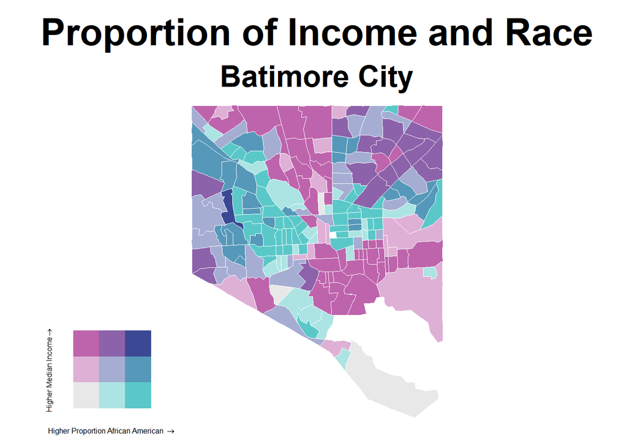

```r
# Creating bivariate legend using cowplot
legend <- bi_legend(pal = "DkBlue",
                    dim = 3,
                    xlab = "Higher Proportion African American ",
                    ylab = "Higher Median Income ",
                    size = 6)

# Combining map with legend
legend_plot <- ggdraw() +
  draw_plot(bi_map, 0, 0, 1, 1) +
  draw_plot(legend, 0.01, .01, 0.3, 0.3)

legend_plot
```

**7. Rinse and repeat for another county of your choosing, using a *different* color scheme. Be sure to use Psuedo-Mercator (3857). (5 points)**

```r
# This gets African American Population and MHHI in 2019 for A.A. county
AA_Data =  get_acs(geography = "tract",
     variables = c("total_population" = "B01003_001", # Total population
                   "black_pop" = "B01001B_001",
                   "med_hh_inc" = "B19013_001" # Median household income
                   ),
     year = 2019,
     survey = "acs5",
     state = c(24),
     county = "Anne Arundel",
     geometry = TRUE, # download the shapefile with the data
     output = "wide")%>% clean_names() # need this 2019
colnames(AA_Data)
```

```
## [1] "geoid"              "name"               "total_population_e"
## [4] "total_population_m" "black_pop_e"        "black_pop_m"
## [7] "med_hh_inc_e"       "med_hh_inc_m"       "geometry"
```

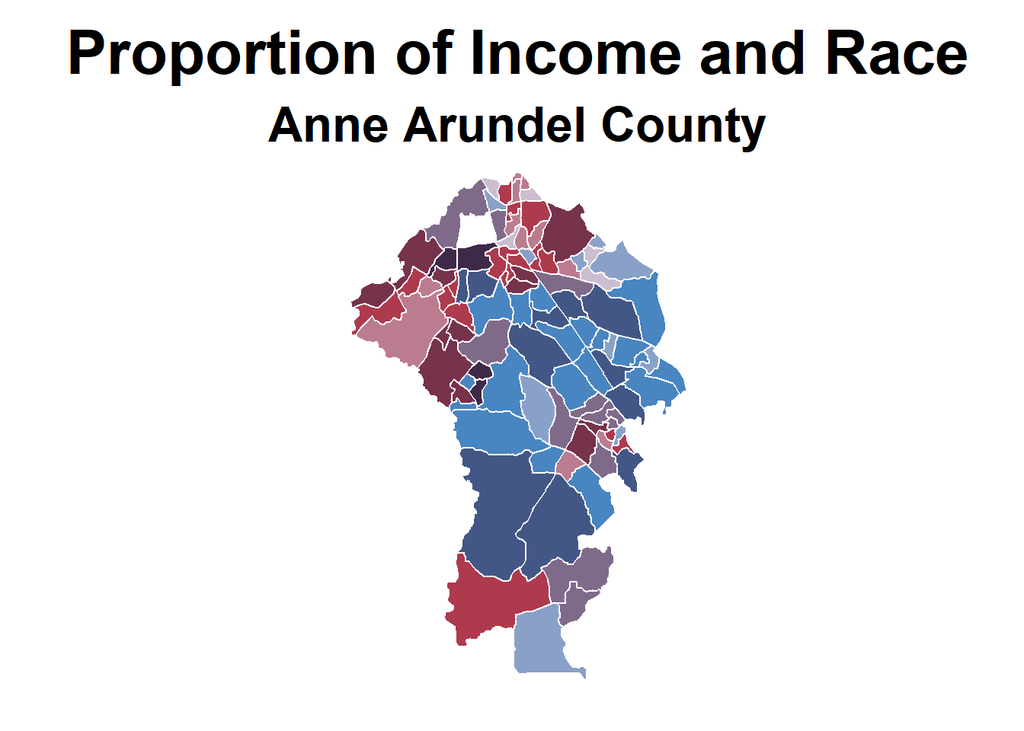

```r
# Measuring census tract with highest AA. proportion
AA_black_pop = AA_Data$black_pop_e[!is.na(AA_Data$black_pop_e)]

# Measuring census tract with highest MHHI
AA_mhhi = AA_Data %>% filter(!is.na(AA_Data$med_hh_inc_e))

# Creating a Bi_class for A.A. County
AA_bi_data = bi_class(AA_mhhi, x= black_pop_e, y = med_hh_inc_e, style = "quantile", dim = 3)

# Mapping Bivariate Data for AA County
AA_bi_map =
  ggplot()+
  geom_sf(data = AA_bi_data, mapping = aes(fill = bi_class), color = "white", size = 0.5, show.legend = FALSE) +
  bi_scale_fill(pal = "DkViolet", dim = 3)+
  labs(
    title = "Proportion of Income and Race",
    subtitle = "Anne Arundel County")+
  bi_theme()


  ggplot()+
  geom_sf(data = AA_bi_data, mapping = aes(fill = bi_class), color = "white", size = 0.5, show.legend = FALSE) +
  bi_scale_fill(pal = "DkViolet", dim = 3)+
  labs(
    title = "Proportion of Income and Race",
    subtitle = "Anne Arundel County")+
  bi_theme()
```

[figure not shown]

```r
# Creating bivariate legend using cowplot
AA_legend <- bi_legend(pal = "DkViolet",
                    dim = 3,
                    xlab = "Higher Proportion African American ",
                    ylab = "Higher Median Income ",
                    size = 6)

# Combining map with legend
AA_legend_plot <- ggdraw() +
  draw_plot(AA_bi_map, 0, 0, 1, 1) +
  draw_plot(AA_legend, 0.01, .01, 0.3, 0.3)

AA_legend_plot
```

**8. Write the bi_class output to a geojson file. (1 points)**

```r
#st_write(AA_bi_data, "Patterson_Lab8.geojson")
```

**9. Now open your geojson output and create a QGIS map of your bivariate map. Put an image of that map here. (2 points)**

```r
# Inserting the image into this Rmarkdown document
img1_path1 <- "C:/Users/vival/Documents/GES 486/Lab8/Patterson_AAcounty.PNG"
img1 <- readPNG(img1_path1, native = TRUE, info = TRUE)
attr(img1, "info")
```

```
## $dim
## [1] 1354  961
##
## $bit.depth
## [1] 8
##
## $color.type
## [1] "RGBA"
##
## $gamma
## [1] 0.45455
##
## $dpi
## [1] 239.9792 239.9792
```

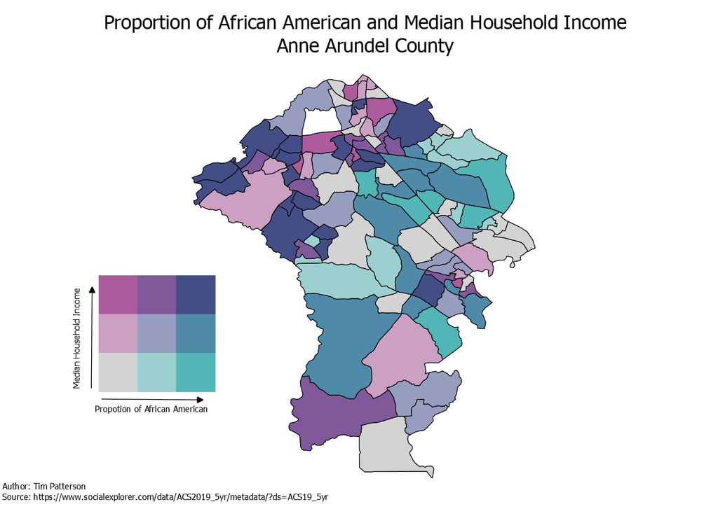

```r
include_graphics(img1_path1)
```

**10. Use qgis2web and put a link here to your github site with the webmap of your bivariate map. (3 points)**

https://github.com/timpatt1/timpatt1.github.io/tree/master/Patterson_Lab9/qgis2web_2021_05_03-20_50_13_088985

## 3. Reflection (3 points)

From this assignment I have gained a better understanding of how the organization of data is detrimental in the work flow process. Taking the time to label code chunks as well as leaving comments allows for you to look back at your code and use it more efficiently in the future. I struggled with that I would like to remember for this assignment is editing specific data within a map. The process of transforming specific data in order to drop and generate variables was very beneficial it allowed me to better edit my map and highlight specific areas of interest. This is something I plan to use for projects in the future.

## 4. Extra Credit (2 points)

**Put an image as a legend in your web map.**

Knit your document to a .html file. Submit this knitted document.